# Assignment7

Yerin Jung

7/9/2018

# 1 Data Preparation

For this assignment, I am going to use credit card data.  
The features here are the same with the ones that I have created for the Assignment 6.

| Agency_Name | Merchant_Category | Median_201307 | Median_201308 | Median_201309 | Median_201310 | Median_201311 | Median_201312 | Median_201401 | Median_201402 | Median_201403 | Median_201404 | Median_201405 | Median_201406 | Max_201307 | Max_201308 | Max_201309 | Max_201310 | Max_201311 | Max_201312 | Max_201401 | Max_201402 | Max_201403 | Max_201404 | Max_201405 | Max_201406 |
| --- | --- | --- | --- | --- | --- | --- | --- | --- | --- | --- | --- | --- | --- | --- | --- | --- | --- | --- | --- | --- | --- | --- | --- | --- | --- |
| ARDMORE HIGHER EDUCATION CENTER | BUSINESS SERVICES NOT ELSEWHERE CLASSIFIED | 0 | 0.000000 | 0.0000000 | 0.00000 | 1.0000000 | 0.000000 | 0.000000 | 0 | 0 | 0 | 0 | 0 | 0 | 0.000000 | 0.0000000 | 0.00000 | 1.0000000 | 0.000000 | 0.000000 | 0 | 0 | 0 | 0 | 0 |
| ARDMORE HIGHER EDUCATION CENTER | CATALOG MERCHANTS | 0 | 2.527739 | 0.0000000 | 1.26387 | 0.4401481 | 0.000000 | 0.000000 | 0 | 0 | 0 | 0 | 0 | 0 | 2.527739 | 0.0000000 | 1.26387 | 0.7361303 | 0.000000 | 0.000000 | 0 | 0 | 0 | 0 | 0 |
| ARDMORE HIGHER EDUCATION CENTER | COMPUTER NETWORK/INFORMATION SERVICES | 0 | 0.000000 | 0.0000000 | 1.00000 | 0.0000000 | 0.000000 | 0.000000 | 0 | 0 | 0 | 0 | 0 | 0 | 0.000000 | 0.0000000 | 1.00000 | 0.0000000 | 0.000000 | 0.000000 | 0 | 0 | 0 | 0 | 0 |
| ARDMORE HIGHER EDUCATION CENTER | DRUG STORES AND PHARMACIES | 0 | 0.000000 | 0.0000000 | 0.00000 | 0.0000000 | 1.000000 | 0.000000 | 0 | 0 | 0 | 0 | 0 | 0 | 0.000000 | 0.0000000 | 0.00000 | 0.0000000 | 1.000000 | 0.000000 | 0 | 0 | 0 | 0 | 0 |
| ARDMORE HIGHER EDUCATION CENTER | GROCERY STORES,AND SUPERMARKETS | 0 | 1.179877 | 0.4214715 | 0.00000 | 0.0000000 | 1.468004 | 2.153971 | 0 | 0 | 0 | 0 | 0 | 0 | 1.958909 | 0.4214715 | 0.00000 | 0.0000000 | 1.851389 | 2.153971 | 0 | 0 | 0 | 0 | 0 |
| ARDMORE HIGHER EDUCATION CENTER | HARDWARE STORES | 1 | 0.000000 | 0.0000000 | 0.00000 | 0.0000000 | 0.000000 | 0.000000 | 0 | 0 | 0 | 0 | 0 | 1 | 0.000000 | 0.0000000 | 0.00000 | 0.0000000 | 0.000000 | 0.000000 | 0 | 0 | 0 | 0 | 0 |

# 2 Autoencoder

In this section,  
- First, I will plot the data set using one hidden layer. Since Autoencoder uses a bottleneck model, we can do dimension-reduction via Autoencoder.  
- Second, I will detect anomalies using the mean squared error between the real value (input) and reconstructed value (output).

To do the above two agendas, I will initiate an h20 model.

```r
h2o.init(nthreads=-1,enable_assertions = FALSE)
```

```
##  Connection successful!
##
## R is connected to the H2O cluster:
##     H2O cluster uptime:         1 days 5 minutes
##     H2O cluster timezone:       America/New_York
##     H2O data parsing timezone:  UTC
##     H2O cluster version:        3.20.0.2
##     H2O cluster version age:    23 days
##     H2O cluster name:           H2O_started_from_R_Jung-yerin_wnm524
##     H2O cluster total nodes:    1
##     H2O cluster total memory:   1.99 GB
##     H2O cluster total cores:    4
##     H2O cluster allowed cores:  4
##     H2O cluster healthy:        TRUE
##     H2O Connection ip:          localhost
##     H2O Connection port:        54321
##     H2O Connection proxy:       NA
##     H2O Internal Security:      FALSE
##     H2O API Extensions:         XGBoost, Algos, AutoML, Core V3, Core V4
##     R Version:                  R version 3.4.3 (2017-11-30)
```

Next, I changed the data frame into an h2o-type data frame.

```r
ccard_hf <- as.h2o(ccard)
```

| Agency_Name | Merchant_Category | Median_201307 | Median_201308 | Median_201309 | Median_201310 | Median_201311 | Median_201312 | Median_201401 | Median_201402 | Median_201403 | Median_201404 | Median_201405 | Median_201406 | Max_201307 | Max_201308 | Max_201309 | Max_201310 | Max_201311 | Max_201312 | Max_201401 | Max_201402 | Max_201403 | Max_201404 | Max_201405 | Max_201406 |
| --- | --- | --- | --- | --- | --- | --- | --- | --- | --- | --- | --- | --- | --- | --- | --- | --- | --- | --- | --- | --- | --- | --- | --- | --- | --- |
| ARDMORE HIGHER EDUCATION CENTER | BUSINESS SERVICES NOT ELSEWHERE CLASSIFIED | 0 | 0.000000 | 0.0000000 | 0.00000 | 1.0000000 | 0.000000 | 0.000000 | 0 | 0 | 0 | 0 | 0 | 0 | 0.000000 | 0.0000000 | 0.00000 | 1.0000000 | 0.000000 | 0.000000 | 0 | 0 | 0 | 0 | 0 |
| ARDMORE HIGHER EDUCATION CENTER | CATALOG MERCHANTS | 0 | 2.527739 | 0.0000000 | 1.26387 | 0.4401481 | 0.000000 | 0.000000 | 0 | 0 | 0 | 0 | 0 | 0 | 2.527739 | 0.0000000 | 1.26387 | 0.7361303 | 0.000000 | 0.000000 | 0 | 0 | 0 | 0 | 0 |
| ARDMORE HIGHER EDUCATION CENTER | COMPUTER NETWORK/INFORMATION SERVICES | 0 | 0.000000 | 0.0000000 | 1.00000 | 0.0000000 | 0.000000 | 0.000000 | 0 | 0 | 0 | 0 | 0 | 0 | 0.000000 | 0.0000000 | 1.00000 | 0.0000000 | 0.000000 | 0.000000 | 0 | 0 | 0 | 0 | 0 |
| ARDMORE HIGHER EDUCATION CENTER | DRUG STORES AND PHARMACIES | 0 | 0.000000 | 0.0000000 | 0.00000 | 0.0000000 | 1.000000 | 0.000000 | 0 | 0 | 0 | 0 | 0 | 0 | 0.000000 | 0.0000000 | 0.00000 | 0.0000000 | 1.000000 | 0.000000 | 0 | 0 | 0 | 0 | 0 |
| ARDMORE HIGHER EDUCATION CENTER | GROCERY STORES,AND SUPERMARKETS | 0 | 1.179877 | 0.4214715 | 0.00000 | 0.0000000 | 1.468004 | 2.153971 | 0 | 0 | 0 | 0 | 0 | 0 | 1.958909 | 0.4214715 | 0.00000 | 0.0000000 | 1.851389 | 2.153971 | 0 | 0 | 0 | 0 | 0 |
| ARDMORE HIGHER EDUCATION CENTER | HARDWARE STORES | 1 | 0.000000 | 0.0000000 | 0.00000 | 0.0000000 | 0.000000 | 0.000000 | 0 | 0 | 0 | 0 | 0 | 1 | 0.000000 | 0.0000000 | 0.00000 | 0.0000000 | 0.000000 | 0.000000 | 0 | 0 | 0 | 0 | 0 |

Then, I split the train and test model.

```r
train_test <- h2o.splitFrame(ccard_hf,
                         ratios = c(0.4, 0.4),
                         seed = 101)

train  <- train_test[[1]]
test1  <- train_test[[2]]
test2 <- train_test[[3]]

features <- colnames(train)
```

```r
model_nn <- h2o.deeplearning(x = features,
                             training_frame = train,
                             model_id = "model_nn",
                             autoencoder = TRUE,
                             seed = 101,
                             hidden = c(10, 2, 10),
                             epochs = 100,
                             activation = "Tanh")
```

## 2.1 Dimensionality Reduction

The below codes represent the way that I used to perform dimensionality reduction.

```r
train_features <- h2o.deepfeatures(model_nn, train, layer = 2) %>%
  as.data.frame()
```

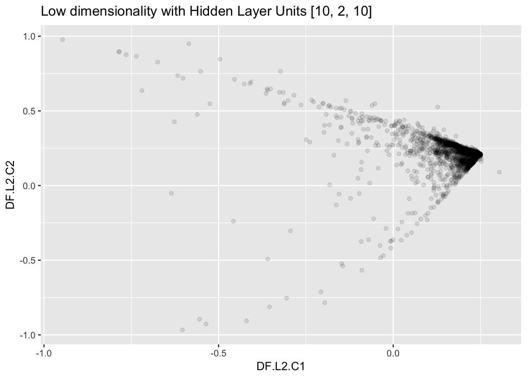

```r
ggplot(train_features, aes(x = DF.L2.C1, y = DF.L2.C2)) +
  geom_point(alpha = 0.1)+
  ggtitle("Low dimensionality with Hidden Layer Units [10, 2, 10]")
```

## 2.2 Anomaly Detection

Now, I am going to build a model to detect anomalies in the data set, using `h2o.anomaly` function.

```r
anomaly <- h2o.anomaly(model_nn, test2) %>%
  as.data.frame() %>%
  tibble::rownames_to_column()
mean_mse <- anomaly %>%
  summarise(mean = mean(Reconstruction.MSE))
```

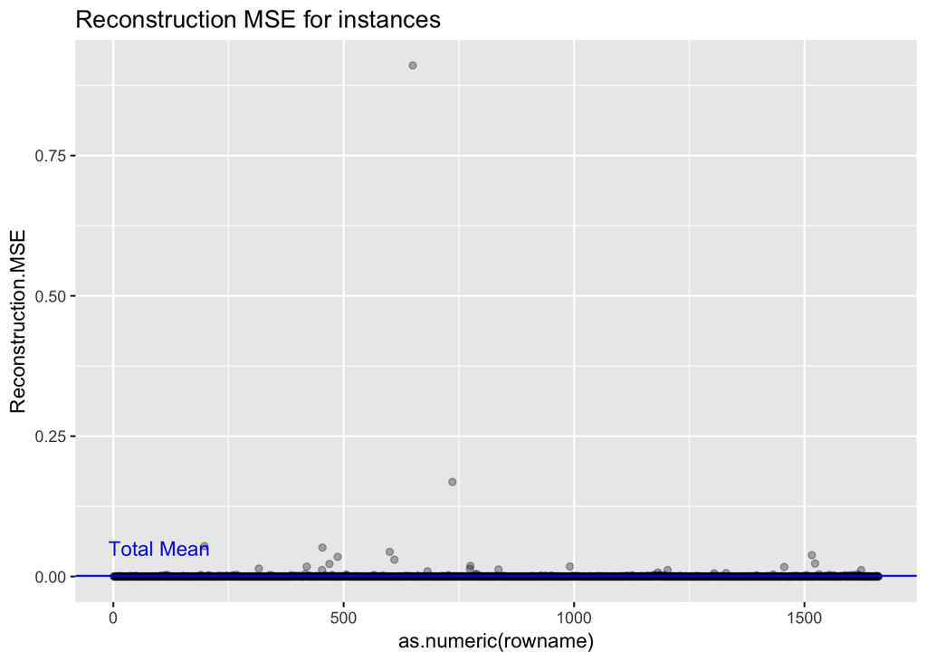

```r
ggplot(anomaly, aes(x = as.numeric(rowname), y = Reconstruction.MSE)) +
  geom_point(alpha = 0.3) +
  geom_hline(data = mean_mse, aes(yintercept = mean), color="blue") +
  annotate(geom="text", x=100, y=0.05, label="Total Mean", color="blue")+
  ggtitle("Reconstruction MSE for instances")
```

As we can see from the below table, $10$ cases were detected as outliers.

| outlier | n |
| --- | --- |
| no_outlier | 1651 |
| outlier | 10 |

To identify the agencies that were detected as outliers, I plotted a histogram.

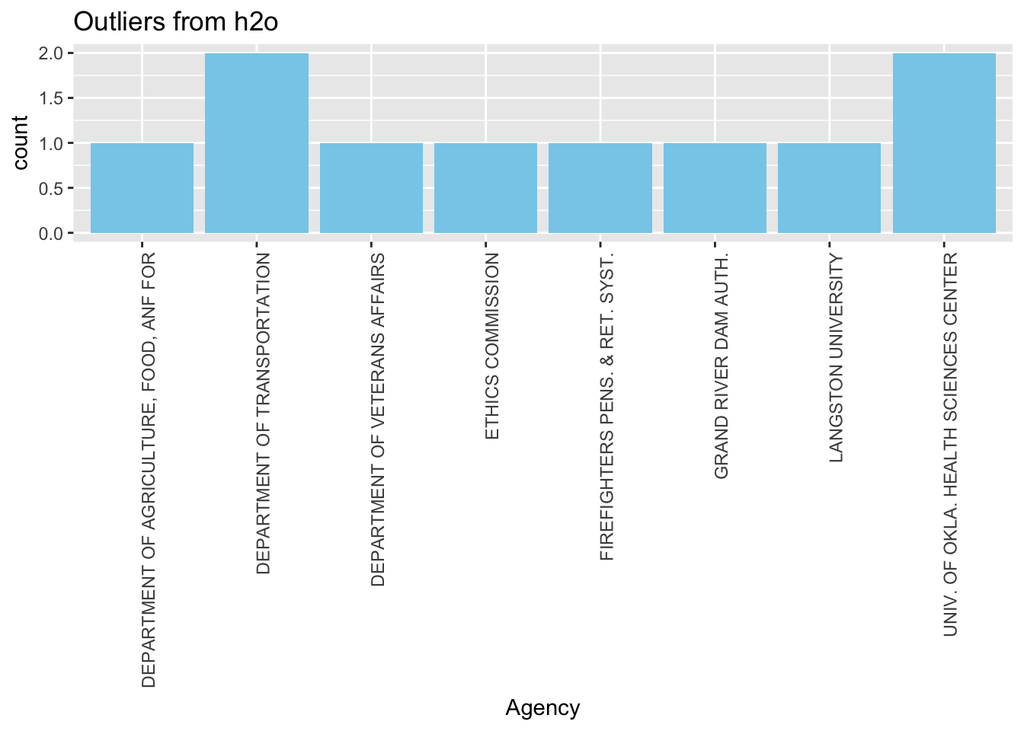

```r
test2_anomaly %>%
  filter(outlier=="outlier")%>%
  ggplot(aes(x=Agency))+
  geom_histogram(stat="count", fill="skyblue")+
  theme(axis.text.x = element_text(angle = 90, hjust = 1))+
  ggtitle("Outliers from h2o")
```

We can find $8$ agencies from the above histogram.

# 3 Mean-Shift

Due to the computational limit, I sampled only 20% of the entire dataset.  
After sampling, I scaled them.

```r
set.seed(101)

ind <-sample(nrow(ccard), floor(nrow(ccard)*0.2))
ccard_sample <- ccard[ind,]
ccard_sd<-scale(ccard_sample[,3:26])
ccard_data <-t(ccard_sd)
dim(ccard_data)
```

```
## [1]   24 1681
```

## 3.1 h=10.0

First, I will try msClustering with `h`=$10$.  
I will gradually increase the size of the bandwidth (10, 15, and 20) and compared the results.

```r
ms_clustering1 <- msClustering( ccard_data, h=10.0 )
```

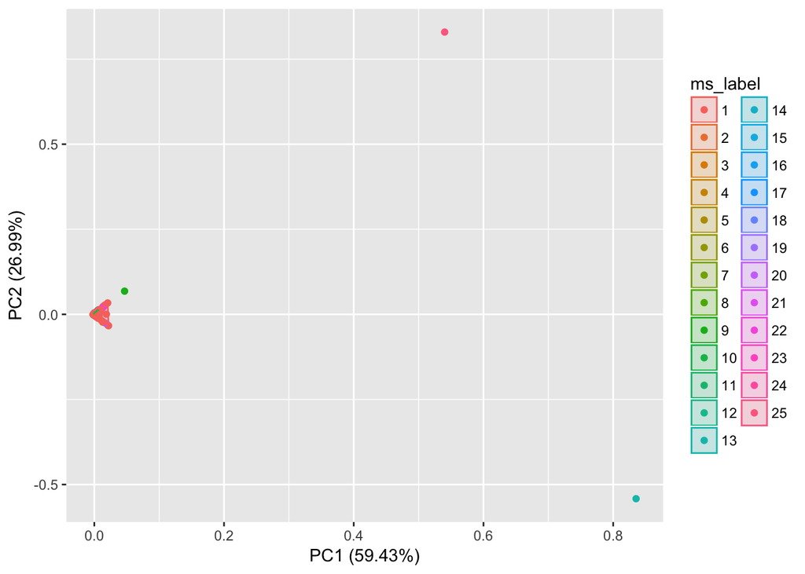

```r
# Plotting using PCA
ccard_ms1 <- ccard_sample
ccard_ms1[,'ms_label'] <- ms_clustering1[2]
ccard_ms1[,'ms_label'] <- as.factor(ccard_ms1$ms_label)
autoplot(prcomp(ccard_ms1[,3:25]), data = ccard_ms1, colour = 'ms_label',frame=TRUE)
```

As we can see from the below table, most of the values are labeled as one, and there were 25 labels in total.

```r
# Counting numbers by label
anomaly_summary <- ccard_ms1 %>%
  group_by(ms_label) %>%
  summarise(n_count=n())


kable(anomaly_summary, "html") %>%
  kable_styling((bootstrap_options = c("striped","hover")), full_width = FALSE, font_size=10)%>%
  scroll_box(width = "500px", height = "300px")
```

| ms_label | n_count |
| --- | --- |
| 1 | 1652 |
| 2 | 3 |
| 3 | 1 |
| 4 | 1 |
| 5 | 1 |
| 6 | 3 |
| 7 | 1 |
| 8 | 1 |
| 9 | 1 |
| 10 | 2 |
| 11 | 1 |
| 12 | 1 |
| 13 | 1 |
| 14 | 1 |
| 15 | 1 |
| 16 | 1 |
| 17 | 1 |
| 18 | 1 |
| 19 | 1 |
| 20 | 1 |
| 21 | 1 |
| 22 | 1 |
| 23 | 1 |
| 24 | 1 |
| 25 | 1 |

Finally, I looked at the name of the agencies, who have been detected as outliers (labeled other than 1).

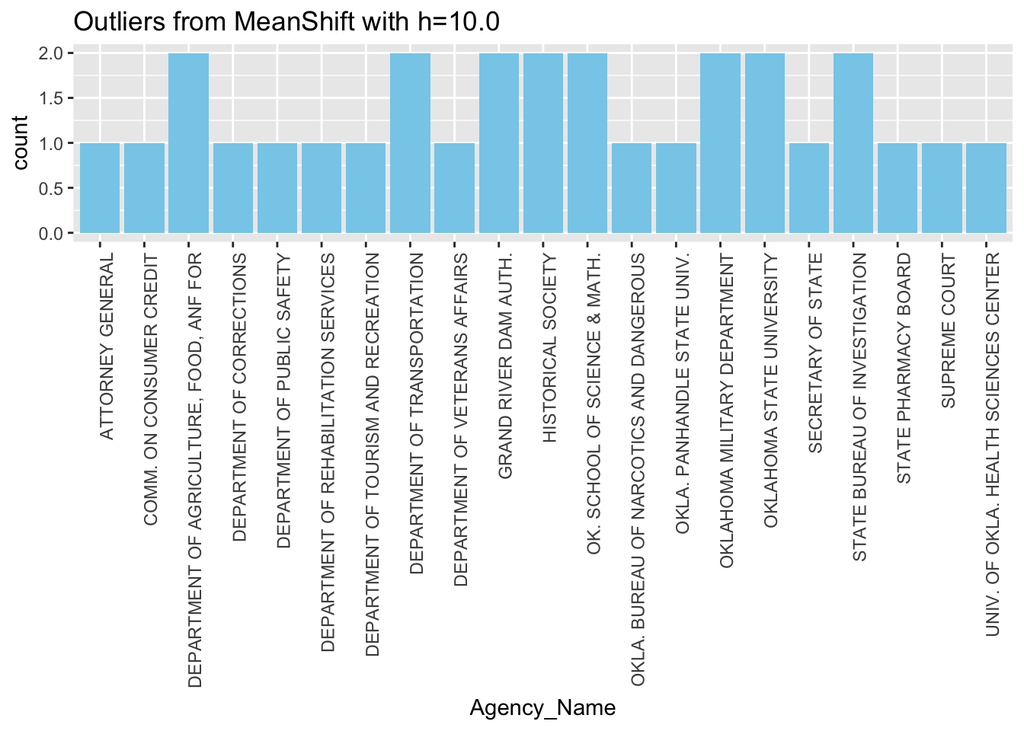

```r
ccard_ms1 %>%
  filter(ms_label != 1) %>%
  ggplot(aes(x=Agency_Name))+
  geom_histogram(stat = "count", fill="skyblue")+
  theme(axis.text.x = element_text(angle = 90, hjust = 1))+
  ggtitle("Outliers from MeanShift with h=10.0")
```

## 3.2 h=15.0

I tried the same approach with the parameter `h`=$15$.

```r
ms_clustering2 <- msClustering( ccard_data, h=15.0 )
```

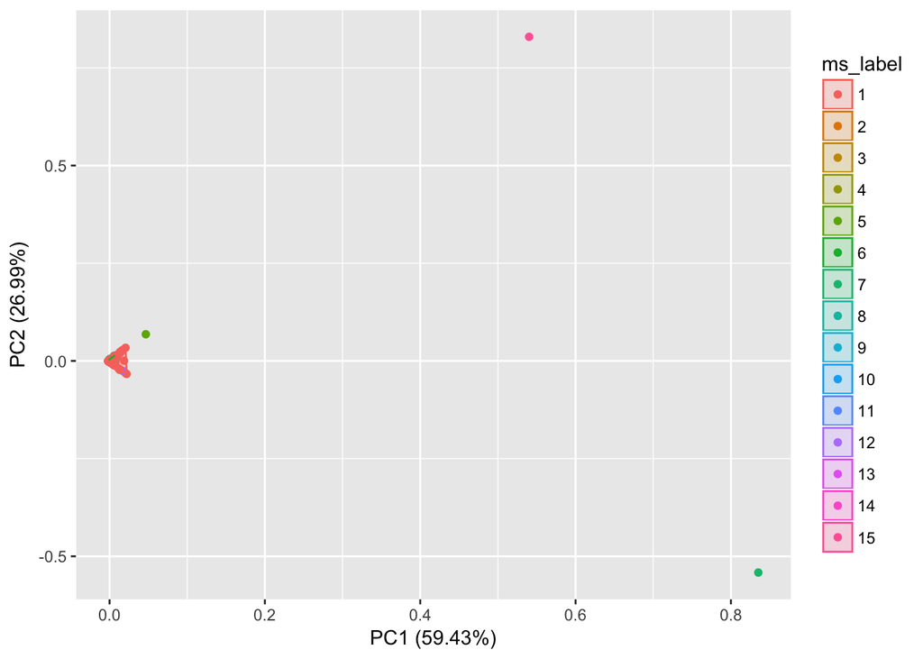

As we can see from the below table, with the parameter `h`=$15$, fewer instances were detected than when `h`=$10$ as outliers (other than 1).

| ms_label | n_count |
| --- | --- |
| 1 | 1665 |
| 2 | 1 |
| 3 | 1 |
| 4 | 1 |
| 5 | 1 |
| 6 | 3 |
| 7 | 1 |
| 8 | 1 |
| 9 | 1 |
| 10 | 1 |
| 11 | 1 |
| 12 | 1 |
| 13 | 1 |
| 14 | 1 |
| 15 | 1 |

Finally, I also looked at the name of the agencies, who have been detected as outliers (labeled other than 1).

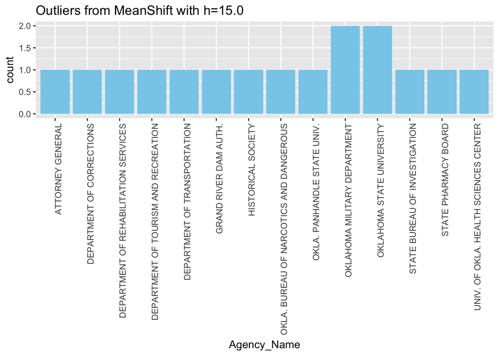

In this case, only `OKLAHOMA STATE UNIVERSITY` and `OKLAHOMA MILITARY DEPARTMENT` have more than 1 outliers.

## 3.3 h=20.0

For the last parameter, I tried the same approach with the parameter `h`=$20$.

```r
ms_clustering3 <- msClustering( ccard_data, h=20.0 )
```

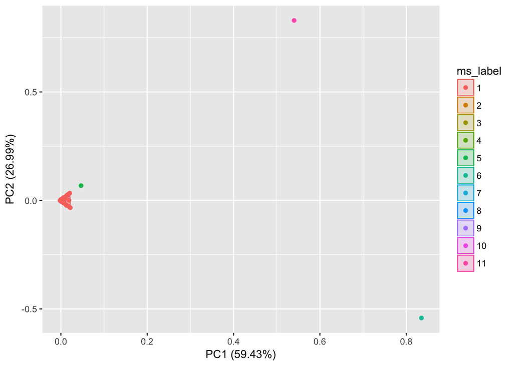

As we can see from the below table, with the parameter `h`=$20$, even fewer instances were detected as outliers (other than 1).  
Only 10 were detected as outliers.

| ms_label | n_count |
| --- | --- |
| 1 | 1671 |
| 2 | 1 |
| 3 | 1 |
| 4 | 1 |
| 5 | 1 |
| 6 | 1 |
| 7 | 1 |
| 8 | 1 |
| 9 | 1 |
| 10 | 1 |
| 11 | 1 |

If we plot the name of the agencies, we can see 10 different agencies.

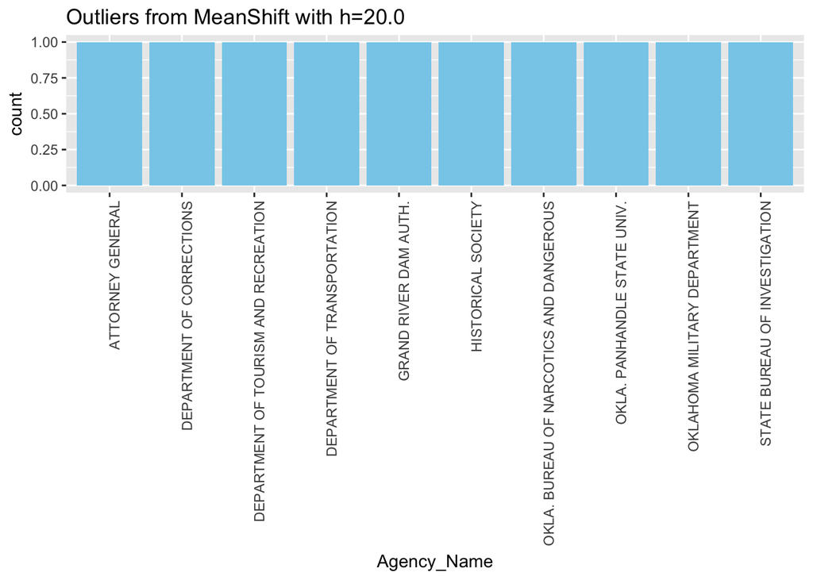

# 4 Autoencoder and Meanshift

Finally, I am going to compare the name of agencies who were detected as anomalies from `MeanShift` and `Autoencoder`.  
I chose `h`=$15$ for `MeanShift`.

As we can see from the below table, there were several agencies who appeared more than once either in each method only or both methods respectively.

```r
ms_agency <- ccard_ms2 %>%
  filter(ms_label != 1) %>%
  dplyr::select(Agency_Name)
names(ms_agency)[1] <-"Agency"

auto_agency <-test2_anomaly %>%
  filter(outlier=="outlier") %>%
  dplyr::select(Agency)

df_combined <- rbind(ms_agency, auto_agency)

final <- df_combined %>% group_by(Agency)%>%
  summarize(count_agency=n())

kable(final, "html") %>%
  kable_styling((bootstrap_options = c("striped","hover")), full_width = FALSE, font_size=10) %>%
  row_spec(c(6, 10, 15, 16, 19), bold = T, color = "white", background = "skyblue")%>%
  scroll_box(width = "500px", height = "300px")
```

| Agency | count_agency |
| --- | --- |
| ATTORNEY GENERAL | 1 |
| DEPARTMENT OF AGRICULTURE, FOOD, ANF FOR | 1 |
| DEPARTMENT OF CORRECTIONS | 1 |
| DEPARTMENT OF REHABILITATION SERVICES | 1 |
| DEPARTMENT OF TOURISM AND RECREATION | 1 |
| DEPARTMENT OF TRANSPORTATION | 3 |
| DEPARTMENT OF VETERANS AFFAIRS | 1 |
| ETHICS COMMISSION | 1 |
| FIREFIGHTERS PENS. & RET. SYST. | 1 |
| GRAND RIVER DAM AUTH. | 2 |
| HISTORICAL SOCIETY | 1 |
| LANGSTON UNIVERSITY | 1 |
| OKLA. BUREAU OF NARCOTICS AND DANGEROUS | 1 |
| OKLA. PANHANDLE STATE UNIV. | 1 |
| OKLAHOMA MILITARY DEPARTMENT | 2 |
| OKLAHOMA STATE UNIVERSITY | 2 |
| STATE BUREAU OF INVESTIGATION | 1 |
| STATE PHARMACY BOARD | 1 |
| UNIV. OF OKLA. HEALTH SCIENCES CENTER | 3 |